# Assignment 2

Betsy Cowdery

2/23/2015

GE516 Assignment # 2 Basic Linear Regression Due: Feb 26 The goal of this assignment is to illustrate the basic concepts of linear regression models, and to estimate some linear models in R. To this end, perform the following tasks and answer the associated questions. Specifically, you will estimate univariate regression models to predict ozone as a function of radiation, temperature and wind (i.e., three models). To do this, use the data provided in the built - in dataframe called “airquality.”

A. Produce scatter plots showing the relationship between ozone and each of the other variables in the dataframe .

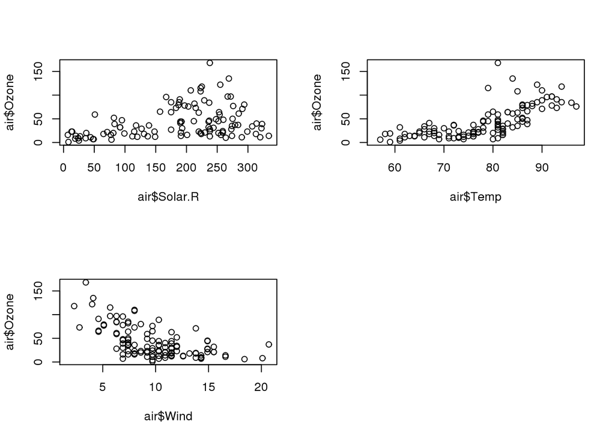

Use the plotting options to correctly label your axes and make your plots clear and easy to understand.

B. Use “lm” to estimate three regression models where ozone as the response variable and radiation, temperature and wind are the predictors.

C. Explain how to interpret the R2, F and p-values provided by R. What do these statistics tell you about each of the models that you have estimated?

```
##
## Call:
## lm(formula = air$Ozone ~ air$Solar.R)
##
## Residuals:
##     Min      1Q  Median      3Q     Max
## -48.292 -21.361  -8.864  16.373 119.136
##
## Coefficients:
##             Estimate Std. Error t value Pr(>|t|)
## (Intercept) 18.59873    6.74790   2.756 0.006856 **
## air$Solar.R  0.12717    0.03278   3.880 0.000179 ***
## ---
## Signif. codes:  0 '***' 0.001 '**' 0.01 '*' 0.05 '.' 0.1 ' ' 1
##
## Residual standard error: 31.33 on 109 degrees of freedom
##   (42 observations deleted due to missingness)
## Multiple R-squared:  0.1213, Adjusted R-squared:  0.1133
## F-statistic: 15.05 on 1 and 109 DF,  p-value: 0.0001793
```

```
##
## Call:
## lm(formula = air$Ozone ~ air$Temp)
##
## Residuals:
##     Min      1Q  Median      3Q     Max
## -40.729 -17.409  -0.587  11.306 118.271
##
## Coefficients:
##              Estimate Std. Error t value Pr(>|t|)
## (Intercept) -146.9955    18.2872  -8.038 9.37e-13 ***
## air$Temp       2.4287     0.2331  10.418  < 2e-16 ***
## ---
## Signif. codes:  0 '***' 0.001 '**' 0.01 '*' 0.05 '.' 0.1 ' ' 1
##
## Residual standard error: 23.71 on 114 degrees of freedom
##   (37 observations deleted due to missingness)
## Multiple R-squared:  0.4877, Adjusted R-squared:  0.4832
## F-statistic: 108.5 on 1 and 114 DF,  p-value: < 2.2e-16
```

```
##
## Call:
## lm(formula = air$Ozone ~ air$Wind)
##
## Residuals:
##     Min      1Q  Median      3Q     Max
## -51.572 -18.854  -4.868  15.234  90.000
##
## Coefficients:
##             Estimate Std. Error t value Pr(>|t|)
## (Intercept)  96.8729     7.2387   13.38  < 2e-16 ***
## air$Wind     -5.5509     0.6904   -8.04 9.27e-13 ***
## ---
## Signif. codes:  0 '***' 0.001 '**' 0.01 '*' 0.05 '.' 0.1 ' ' 1
##
## Residual standard error: 26.47 on 114 degrees of freedom
##   (37 observations deleted due to missingness)
## Multiple R-squared:  0.3619, Adjusted R-squared:  0.3563
## F-statistic: 64.64 on 1 and 114 DF,  p-value: 9.272e-13
```

D. Use R to manually (i.e., based on the equations given in class) compute the values for the F-statistic, β0, and β1 for your regression model predicting ozone as a function of temperature.

You may use lm to verify your results, but the objective is to compute these statistics from the data themselves.

E. For each model, manually perform the diagnostic regression assessments that we talked about in class (i.e., examine the residuals). To do this, you may use the built-in functionality of R to check your results, but you must also do this yourself by generating diagnostic plots of the residuals from the model. Specifically, use the “plot” command and the “qqnorm” command to plot fitted versus values versus residuals and to generate a qqnorm plot of the residuals. Comment on what you find.

Specifically,

1.Does the model appear to meet the required assumptions? If so, why? If not, why not?

2. Are any of the data points candidate outliers? Delete one or two extreme points and assess the sensitivity of the model to these points. Explain what you find.

# Model 1

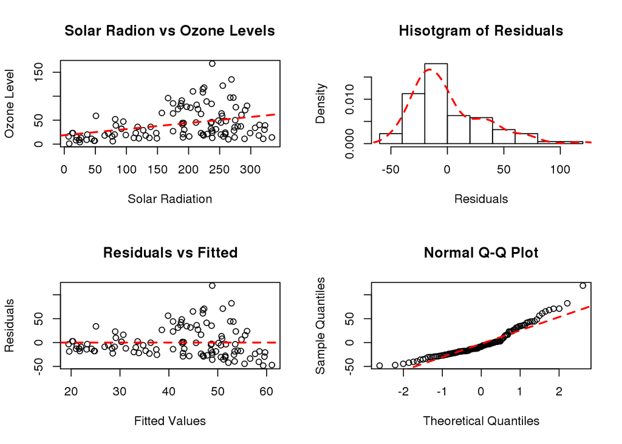

# Model 2

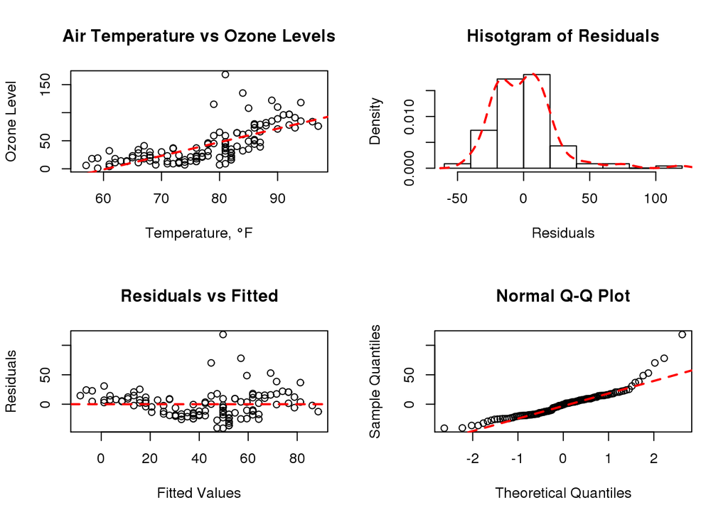

# Model 3

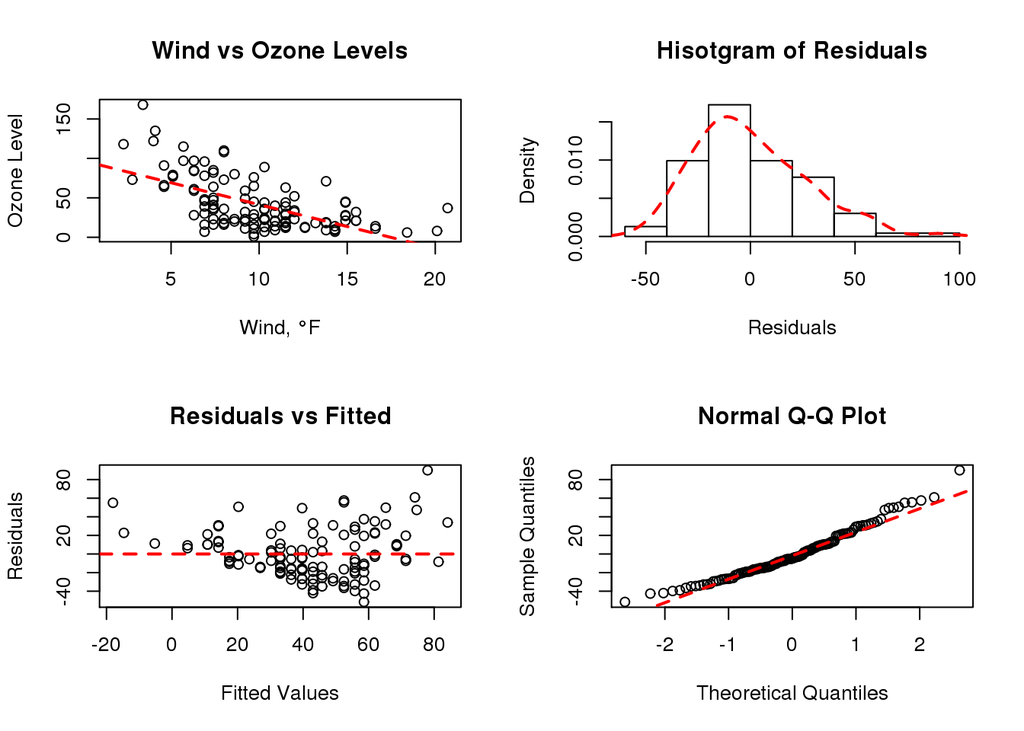